# A framework for evaluating edited cell libraries created by massively parallel genome engineering

Figures for main section

# Figure 3

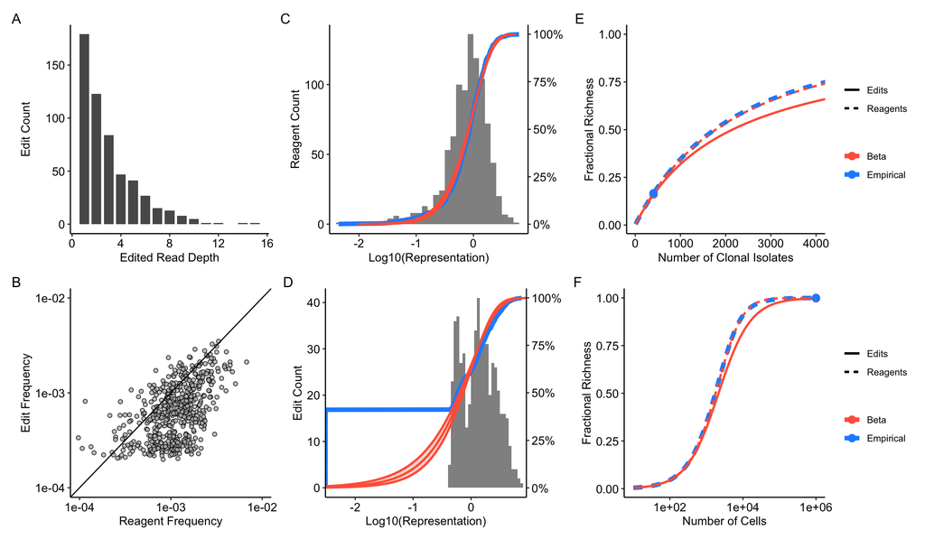

Example usage of pWGS and design reagent amplicon sequencing assays to characterize an E. coli edit library. After exclusion of controls, the library consists of 928 designs including insertions, deletions and substitutions spanning the genome. The resulting edits are not expected to result in any notable effects on cellular fitness.

**A:** Number of sequencing reads with exact match to expected edits in a pWGS run. The pWGS run included 157M 2x150 read pairs. After exclusion of reads failing quality filters the mean coverage depth fully spanning the targeted edits is 3434. Summing the per-locus edit fractions produces an estimate of 0.44 for the overall fraction of edited cells in the pool, thus the pWGS run profiles approximately 1501 genomes’ worth of DNA overall. A total of 1615 edited reads is seen, comprising 546 unique edits.

**B:** Scatterplot comparing the edit frequencies estimated from pWGS with design frequencies estimated from amplicon sequencing of reagents.

**C:** Histogram and cumulative distribution function (CDF) of design representation (defined as the product of design frequency and library size), measured by amplicon sequencing of the design reagents. The assay consists of 3.0M reads. Fitting the design frequencies to a beta distribution via maximum likelihood estimation (MLE), the data are well described by a beta distribution with mean 1/928 and CV 0.73.

**D:** Histogram and CDF as in C, but for the representation of edits as measured by pWGS. Given that the pWGS run is sampling roughly 1501 genomes’ worth of DNA per locus, it should be viewed as a sampling of mainly the right tail of the edit frequency distribution. The fraction of the edit library that is observed at least once is 0.59. Fitting edit frequencies with a beta distribution via MLE, the estimate of CV is 1.01. Observation of a greater fraction of all possible edits in the library would require substantially more sequencing. For example, if the goal were to directly observe 90% of the edits in pWGS, it would require detection of edits whose frequencies among the 44% of edited cells is around the 10th percentile of the design frequency distribution, or 1e-4. Aiming for an expected edit read count of 10, to have a reasonable chance of observing edits at the 10th percentile, it would take a mean coverage depth of 213K. This is 62-fold larger than the actual coverage depth for the pWGS run, which would require a total sequencing throughput of 9.8B read pairs.

**F:** Selector’s curve, showing the same data as in E but with the x-axis changed to log scale and domain extended to cover the deep sampling that is typically relevant for selection applications. The solid point indicated on the curve corresponds to the Selector’s score, which is the fractional richness when sampling 1M cells.

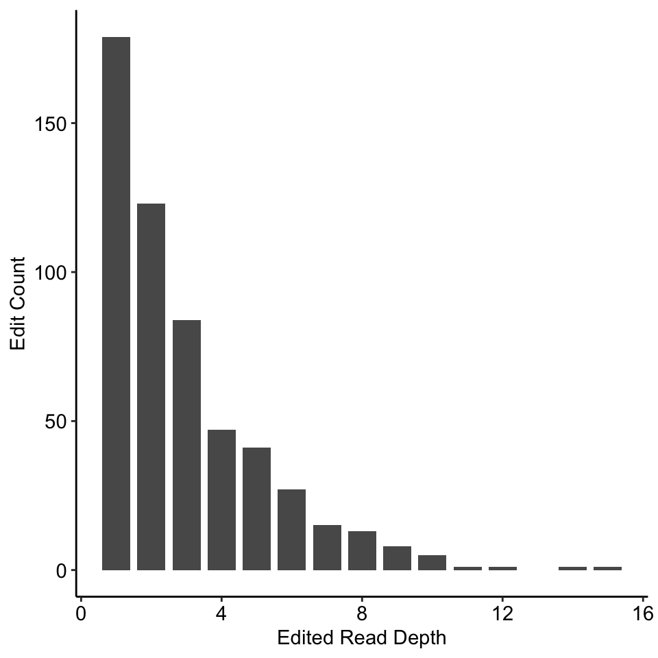

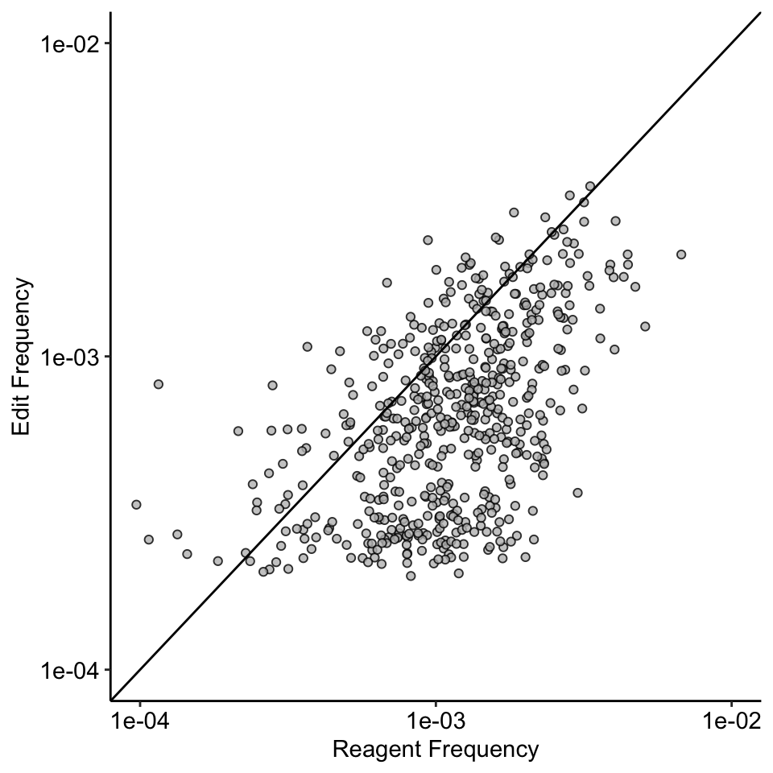

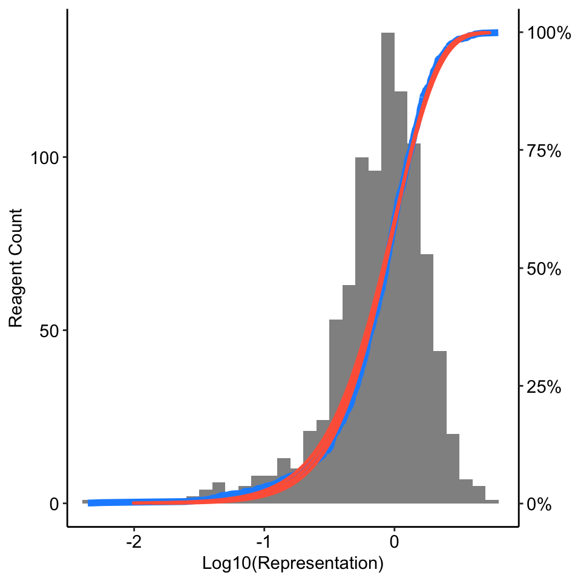

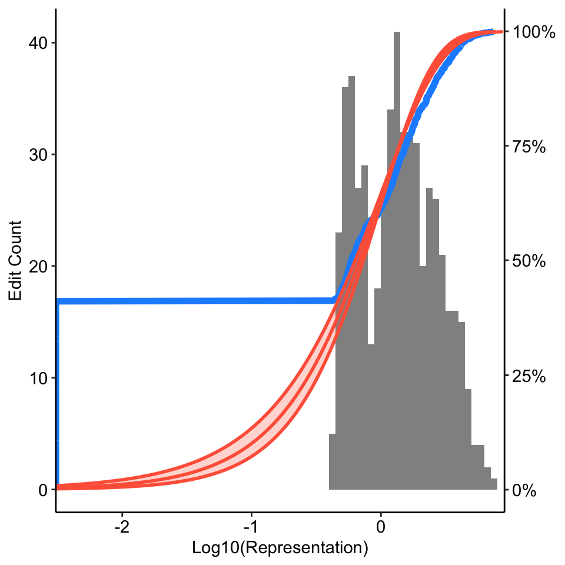

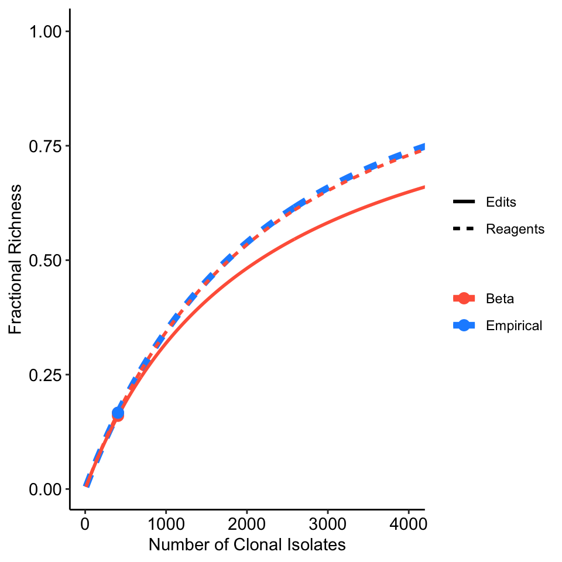

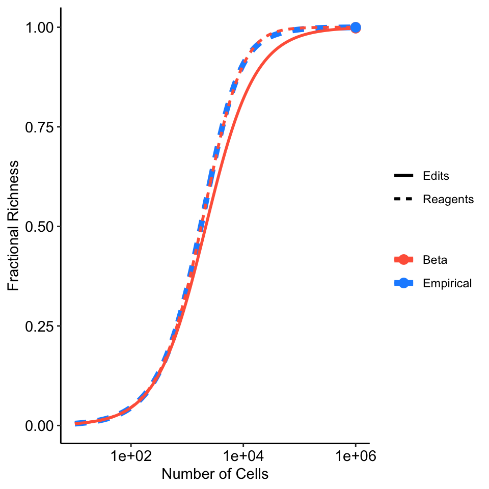

# Figure 4

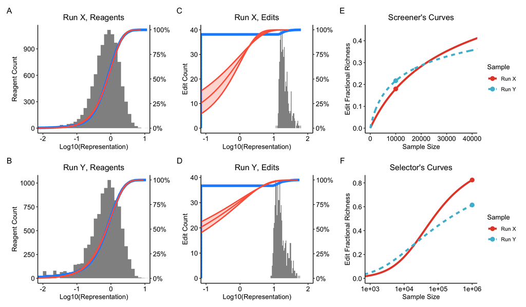

Comparative evaluation of two runs of a 10,000 member E. coli library, the runs are named X and Y. A and B: histogram and CDF (blue) of design frequencies as determined by deep amplicon sequencing of the reagents. The red curves correspond to beta distributions fit by Maximum Likelihood Estimation (MLE). The estimates for design CV are 0.79 and 0.9 for runs X and Y respectively. C and D: histogram and CDF (blue) of genomic edit frequences as determined by pWGS. The red curves are beta distributions fit by MLE, the shaded area spans the 95% confidence interval for the edit CV estimates. The estimated edit CVs are 1.54 and 2.48 for runs X and Y respectively. The pWGS assay is a shallow sampling of edits, with an estimated sampling depth of 488 and 724 in runs X and Y respectively, which is very small compared to the library size of 10,000. The pWGS assay also enables estimation of edit fraction, the estimates are 0.25 and 0.57 for runs X and Y. Run X has a lower edit fraction but also a lower edit CV compared to run Y, so determination of which run is better to use in downstream applications will depend on the situation. E: Screener’s curves plotting predicted fractional richness against sample size for the two runs. The points on the curves correspond to the Screener’s scores using the estimated edit fractions. For a screen of 20,000 or fewer isolates (twice the library size), run Y is predicted to yield greater fractional richness, with its larger edit fraction making up for its larger edit CV F: Selector’s curves, like E but with the x-axis expanded to span a range more typical for a selection application.  
The points on the curves annotate the Selector’s Score, the predicted fractional richness when sampling 1e6 cells. The lower edit CV of run X makes it a better choice for a selection application, despite it having less than half the edit fraction of run Y.

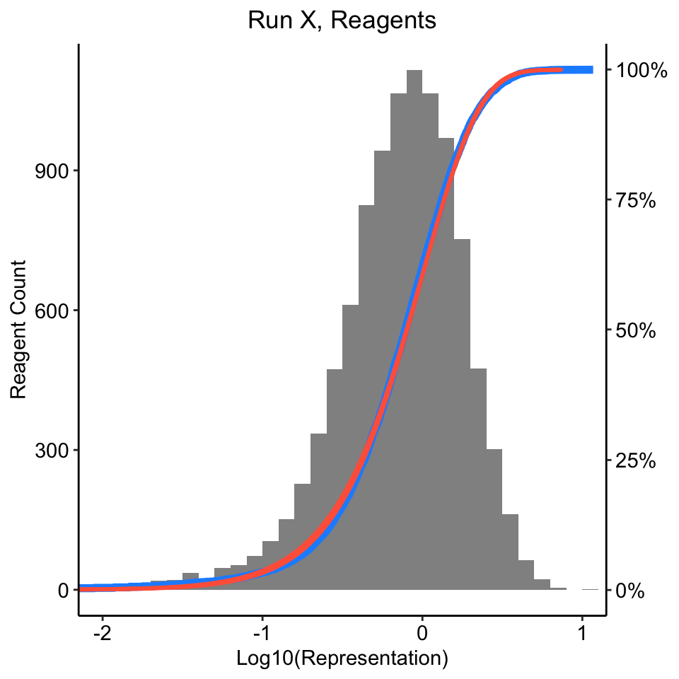

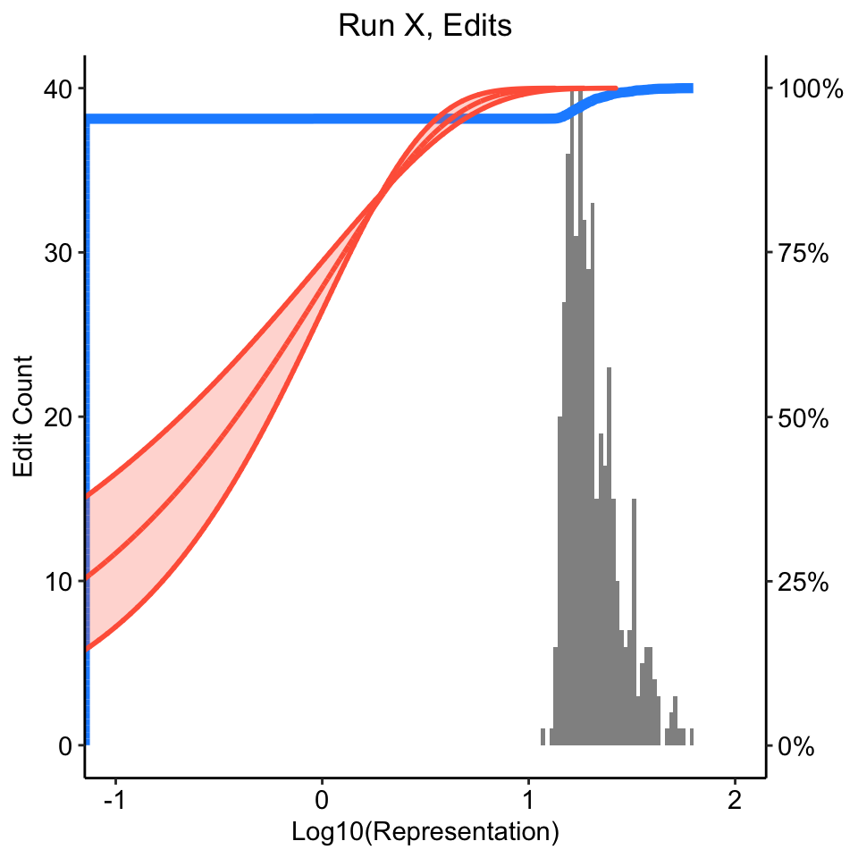

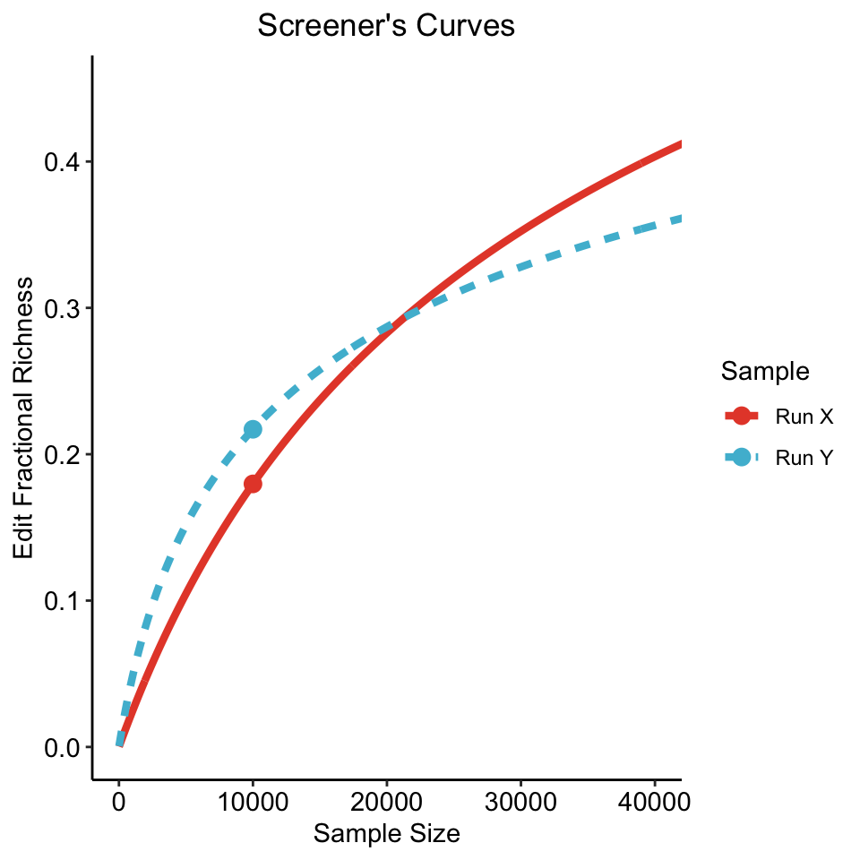

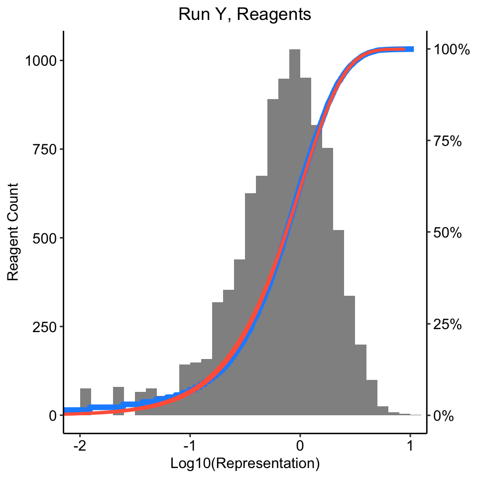

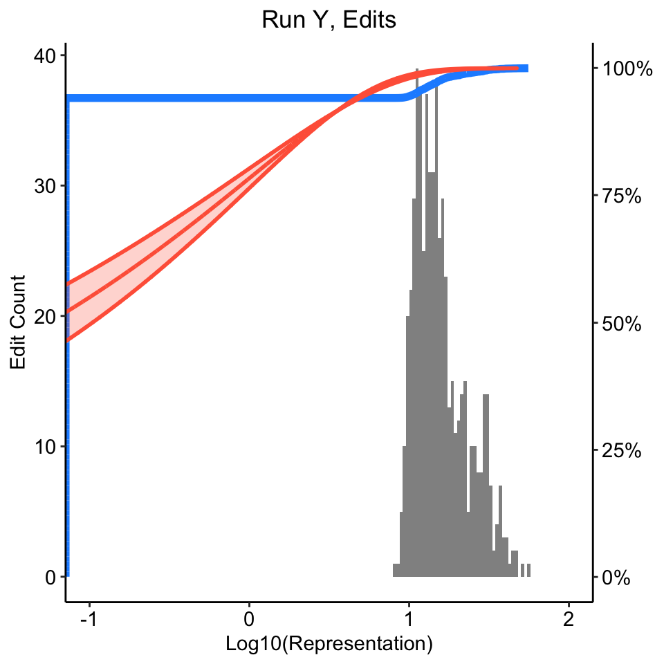

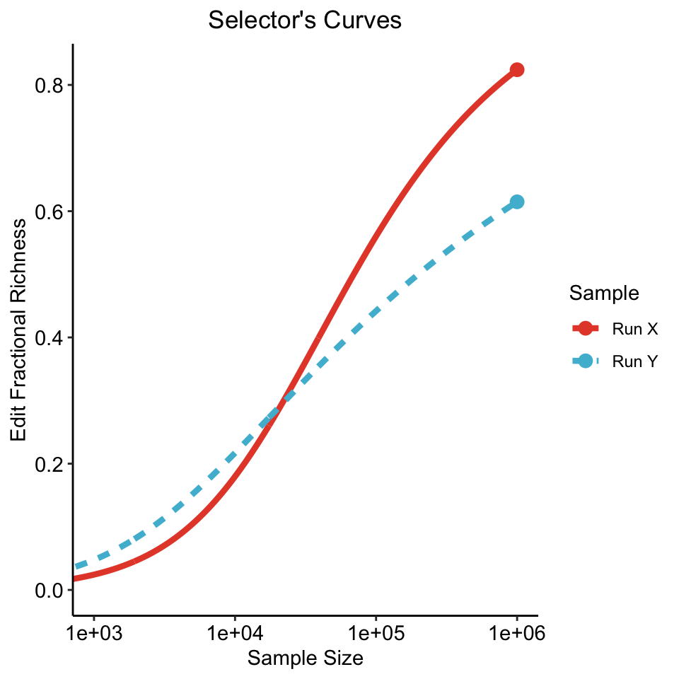

# Figure 5

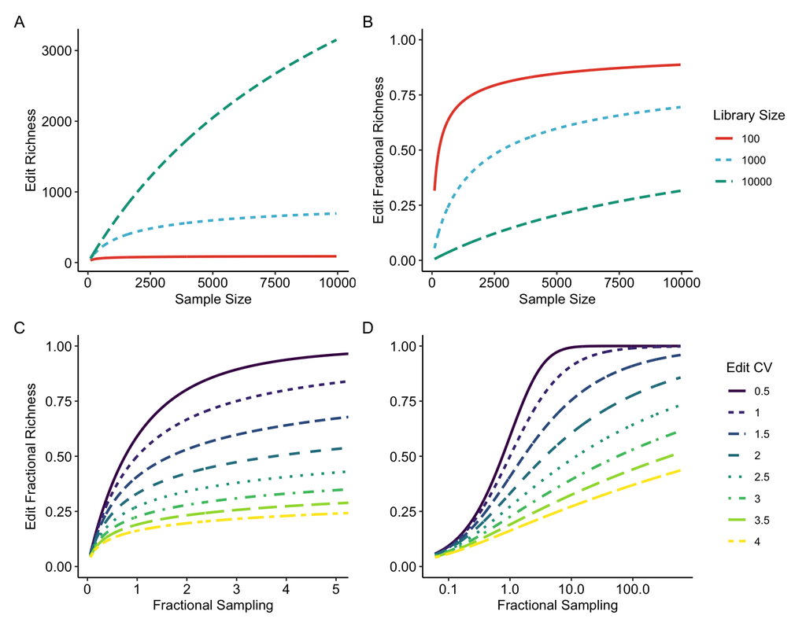

Exploration of richness under the assumption that edit frequencies follow a beta distribution. **A:** Richness for different library sizes, assuming an edit CV of 1.5 and an edit fraction of 0.6. **B:** Fractional richness for the same scenarios as used in **A**. **C:** Screener’s curves, showing fractional richness as a function of fractional sampling, with different values for edit CV. Fractional sampling is defined as the product of sampling depth and edit fraction divided by the library size, along with CV it is all that is required to predict fractional richness under the beta assumption. **D:** Selector’s curves, which are the same figure as **C** with a log-scale x-axis to enable prediction of fractional richness with the deep sampling that is typically used for a selection experiment.

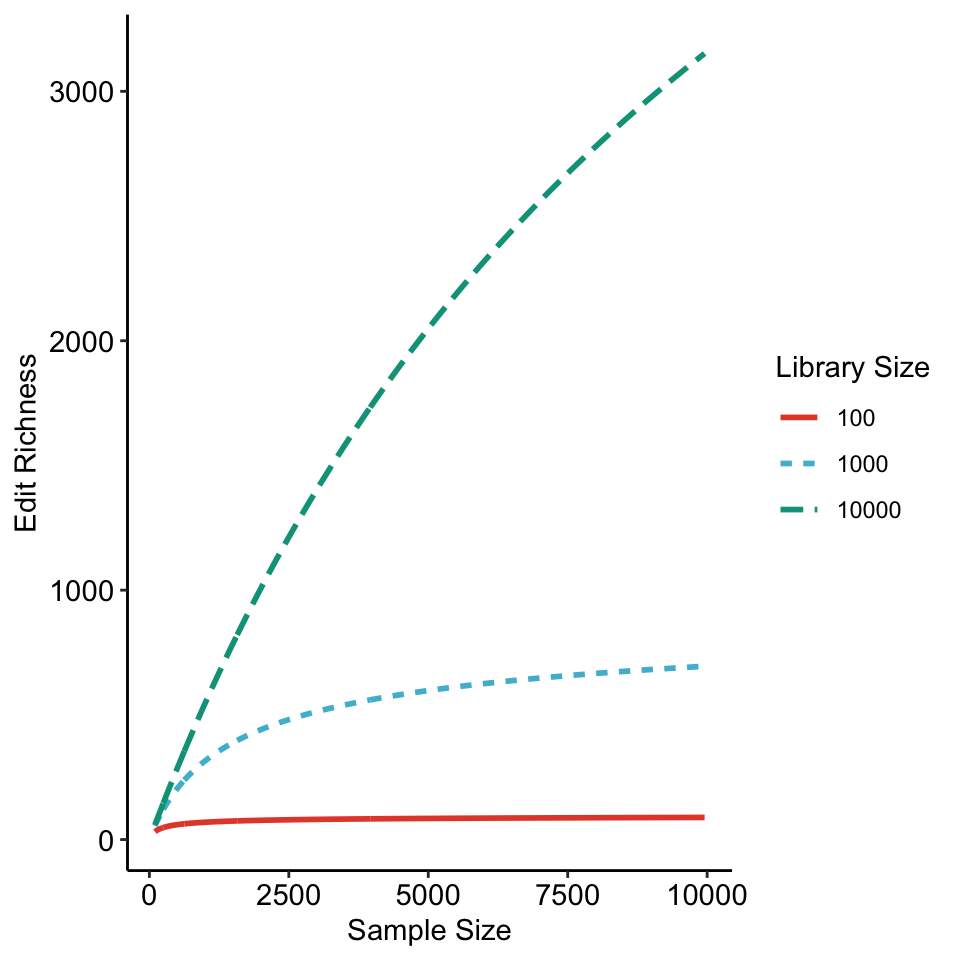

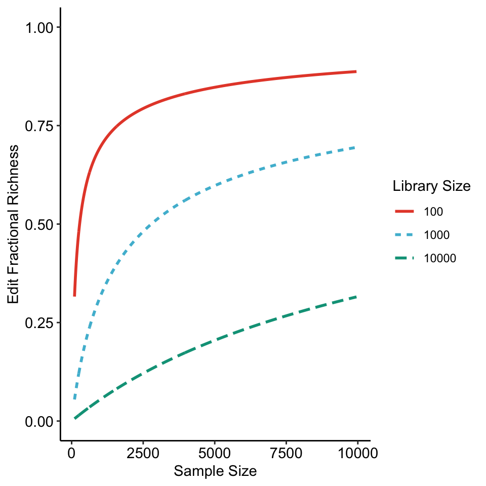

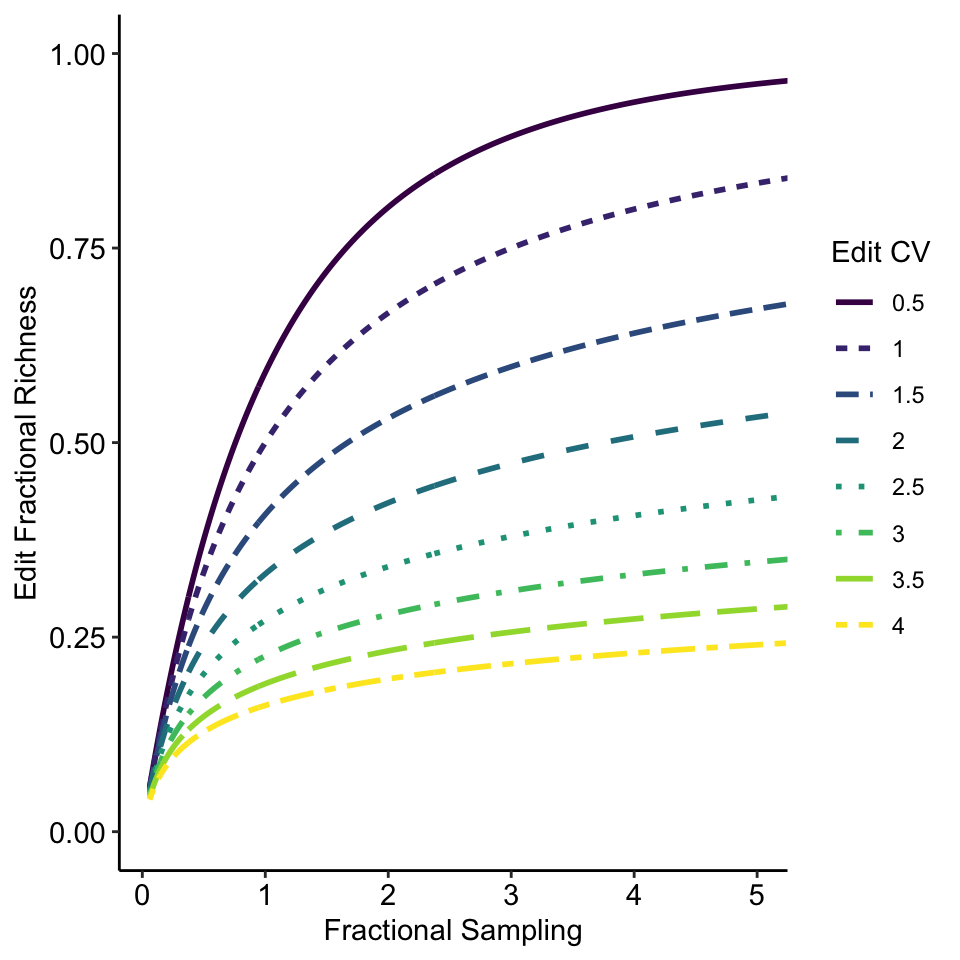

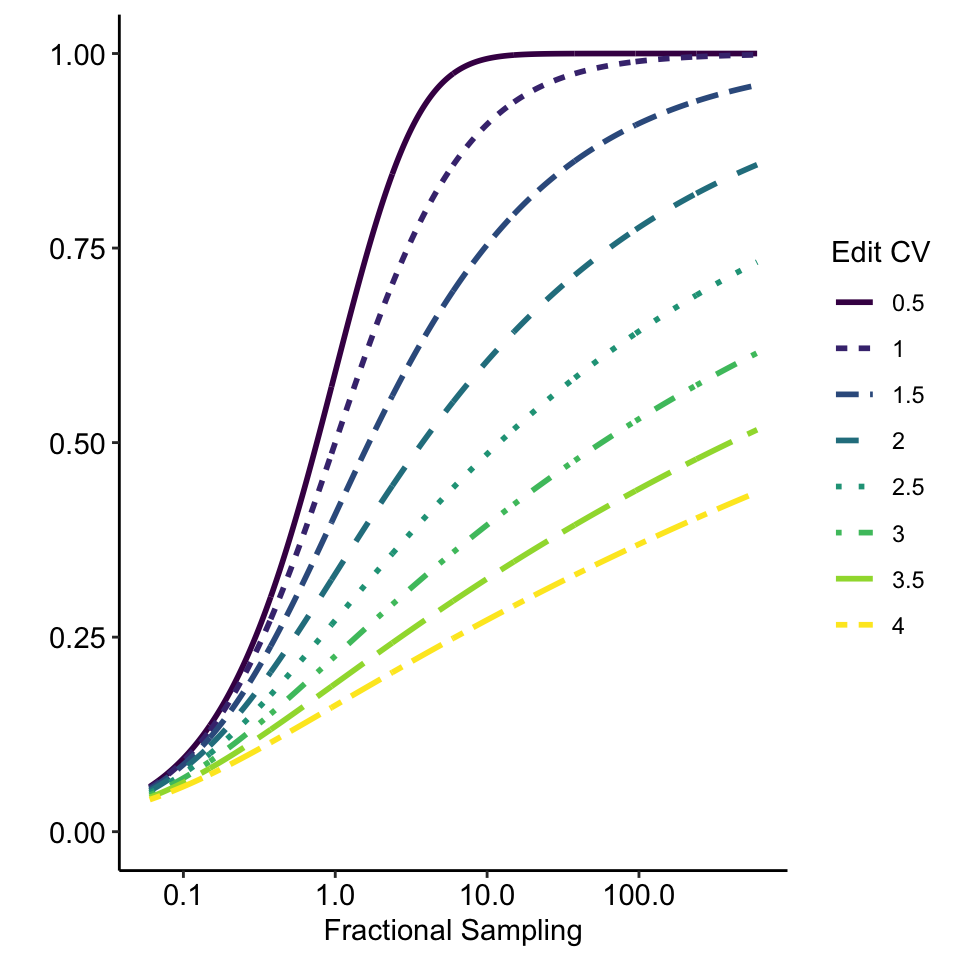